# Project 2: Investigate a Dataset (Movie Analysis)

- Introduction
- Data Wrangling
- Exploratory Data Analysis
- Conclusions

## Introduction

In this project, I have analysed TMDB dataset, which is available on Kaggle. This dataset contains information related to arround 10,000 movies collected from TMDB (www.themoviedb.org). It includes information about movie's budget, revenue, viewer's rating, genres, production companies, director, casting, keywords associated with movies, popularity of the movies and runtime.

This dataset can help to understand various factors like profitability, the trend around runtime, popularity over the years; popular genres for the profitability, connection between popularity ratings and profit; reveal information like profitable directors, casts and production companies over the span.

**Note:** For this analysis, inferential statistics or machine learning are not used so findings are tentative.

I am focusing on answering following questions as part of this project:

- 1. What is the trend of number of movies release each year?
- 2. Is that certain casts and director work together to make profitable movies?
- 3. What are the most profitable, highest revenue and highest budget movies?
- 4. What is the highest revenue movie in each of recent years?
- 5. What is the corelation between budget, revenue and profit in recent years?
- Which Genres are more profitable in recent years?
- 7. Which are some of the most used keywords recent in profitable movies?

```python
# Load your data and print out a few lines. Perform operations to inspect data
#   types and look for instances of missing or possibly errant data.

#importing packages

import numpy as np
import pandas as pd
import matplotlib.pyplot as plt
import seaborn as sns
%matplotlib inline

# Style and size of graph

sns.set_style('darkgrid')
sns.set(rc={'figure.figsize':(10,8)})
```

## Data Wrangling

> **During this step, we are going to import the csv file and display its main information. We will perform the following steps:**
> - Display the info of the dataset and get the idea of the size, number of records and number of columns
> - Familiarize with the dataset and find any unusal values

```python
# After discussing the structure of the data and any problems that need to be
#   cleaned, perform those cleaning steps in the second part of this section.

#importing csv dataset

df = pd.read_csv('tmdb-movies.csv')
print("Original TMDB Dataset contains (Rows,Columns) : ",df.shape)
df.shape
```

```
Original TMDB Dataset contains (Rows,Columns) :  (10866, 21)
```

```
(10866, 21)
```

```python
df.head()
```

|  | id | imdb_id | popularity | budget | revenue | original_title | cast | homepage | director | tagline | ... | overview | runtime | genres | production_companies | release_date | vote_count | vote_average | release_year | budget_adj | revenue_adj |
| --- | --- | --- | --- | --- | --- | --- | --- | --- | --- | --- | --- | --- | --- | --- | --- | --- | --- | --- | --- | --- | --- |
| 0 | 135397 | tt0369610 | 32.985763 | 150000000 | 1513528810 | Jurassic World | Chris Pratt\|Bryce Dallas Howard\|Irrfan Khan\|Vi... | http://www.jurassicworld.com/ | Colin Trevorrow | The park is open. | ... | Twenty-two years after the events of Jurassic ... | 124 | Action\|Adventure\|Science Fiction\|Thriller | Universal Studios\|Amblin Entertainment\|Legenda... | 6/9/15 | 5562 | 6.5 | 2015 | 1.379999e+08 | 1.392446e+09 |
| 1 | 76341 | tt1392190 | 28.419936 | 150000000 | 378436354 | Mad Max: Fury Road | Tom Hardy\|Charlize Theron\|Hugh Keays-Byrne\|Nic... | http://www.madmaxmovie.com/ | George Miller | What a Lovely Day. | ... | An apocalyptic story set in the furthest reach... | 120 | Action\|Adventure\|Science Fiction\|Thriller | Village Roadshow Pictures\|Kennedy Miller Produ... | 5/13/15 | 6185 | 7.1 | 2015 | 1.379999e+08 | 3.481613e+08 |
| 2 | 262500 | tt2908446 | 13.112507 | 110000000 | 295238201 | Insurgent | Shailene Woodley\|Theo James\|Kate Winslet\|Ansel... | http://www.thedivergentseries.movie/#insurgent | Robert Schwentke | One Choice Can Destroy You | ... | Beatrice Prior must confront her inner demons ... | 119 | Adventure\|Science Fiction\|Thriller | Summit Entertainment\|Mandeville Films\|Red Wago... | 3/18/15 | 2480 | 6.3 | 2015 | 1.012000e+08 | 2.716190e+08 |
| 3 | 140607 | tt2488496 | 11.173104 | 200000000 | 2068178225 | Star Wars: The Force Awakens | Harrison Ford\|Mark Hamill\|Carrie Fisher\|Adam D... | http://www.starwars.com/films/star-wars-episod... | J.J. Abrams | Every generation has a story. | ... | Thirty years after defeating the Galactic Empi... | 136 | Action\|Adventure\|Science Fiction\|Fantasy | Lucasfilm\|Truenorth Productions\|Bad Robot | 12/15/15 | 5292 | 7.5 | 2015 | 1.839999e+08 | 1.902723e+09 |
| 4 | 168259 | tt2820852 | 9.335014 | 190000000 | 1506249360 | Furious 7 | Vin Diesel\|Paul Walker\|Jason Statham\|Michelle ... | http://www.furious7.com/ | James Wan | Vengeance Hits Home | ... | Deckard Shaw seeks revenge against Dominic Tor... | 137 | Action\|Crime\|Thriller | Universal Pictures\|Original Film\|Media Rights ... | 4/1/15 | 2947 | 7.3 | 2015 | 1.747999e+08 | 1.385749e+09 |

5 rows × 21 columns

```python
#check basis information of the dataset
print("Quick look at the dataset for some statistical values: \n\n")
df.describe()
```

```
Quick look at the dataset for some statistical values:
```

|  | id | popularity | budget | revenue | runtime | vote_count | vote_average | release_year | budget_adj | revenue_adj |
| --- | --- | --- | --- | --- | --- | --- | --- | --- | --- | --- |
| count | 10866.000000 | 10866.000000 | 1.086600e+04 | 1.086600e+04 | 10866.000000 | 10866.000000 | 10866.000000 | 10866.000000 | 1.086600e+04 | 1.086600e+04 |
| mean | 66064.177434 | 0.646441 | 1.462570e+07 | 3.982332e+07 | 102.070863 | 217.389748 | 5.974922 | 2001.322658 | 1.755104e+07 | 5.136436e+07 |
| std | 92130.136561 | 1.000185 | 3.091321e+07 | 1.170035e+08 | 31.381405 | 575.619058 | 0.935142 | 12.812941 | 3.430616e+07 | 1.446325e+08 |
| min | 5.000000 | 0.000065 | 0.000000e+00 | 0.000000e+00 | 0.000000 | 10.000000 | 1.500000 | 1960.000000 | 0.000000e+00 | 0.000000e+00 |
| 25% | 10596.250000 | 0.207583 | 0.000000e+00 | 0.000000e+00 | 90.000000 | 17.000000 | 5.400000 | 1995.000000 | 0.000000e+00 | 0.000000e+00 |
| 50% | 20669.000000 | 0.383856 | 0.000000e+00 | 0.000000e+00 | 99.000000 | 38.000000 | 6.000000 | 2006.000000 | 0.000000e+00 | 0.000000e+00 |
| 75% | 75610.000000 | 0.713817 | 1.500000e+07 | 2.400000e+07 | 111.000000 | 145.750000 | 6.600000 | 2011.000000 | 2.085325e+07 | 3.369710e+07 |
| max | 417859.000000 | 32.985763 | 4.250000e+08 | 2.781506e+09 | 900.000000 | 9767.000000 | 9.200000 | 2015.000000 | 4.250000e+08 | 2.827124e+09 |

```python
#Check column names and types
print("Column name with number of null values, count of value in each column and data type: \n\n")
df.info()
```

```
Column name with number of null values, count of value in each column and data type:


<class 'pandas.core.frame.DataFrame'>
RangeIndex: 10866 entries, 0 to 10865
Data columns (total 21 columns):
 #   Column                Non-Null Count  Dtype
---  ------                --------------  -----
 0   id                    10866 non-null  int64
 1   imdb_id               10856 non-null  object
 2   popularity            10866 non-null  float64
 3   budget                10866 non-null  int64
 4   revenue               10866 non-null  int64
 5   original_title        10866 non-null  object
 6   cast                  10790 non-null  object
 7   homepage              2936 non-null   object
 8   director              10822 non-null  object
 9   tagline               8042 non-null   object
 10  keywords              9373 non-null   object
 11  overview              10862 non-null  object
 12  runtime               10866 non-null  int64
 13  genres                10843 non-null  object
 14  production_companies  9836 non-null   object
 15  release_date          10866 non-null  object
 16  vote_count            10866 non-null  int64
 17  vote_average          10866 non-null  float64
 18  release_year          10866 non-null  int64
 19  budget_adj            10866 non-null  float64
 20  revenue_adj           10866 non-null  float64
dtypes: float64(4), int64(6), object(11)
memory usage: 1.7+ MB
```

### Movie Data Cleaning and preparing for the data analysis

**Observations based on accessing the TMDB dataset file**

**Steps to clean the data**

> - Drop not required columns for this analysis.
> - Delete rows with NaN values.
> - Delete Duplicate values.
> - Changing format of release date into datetime format.
> - Change format of budget_adj and revenue_adj to int from float.

```python
#drop not required columns for this analysis

df.drop(['id','imdb_id','homepage','tagline','overview'], axis=1, inplace=True)
print("Sample first five rows after deleting - 'id',imdb_id','homepage','tagline','overview':\n\n ")
df.head()
```

```
Sample first five rows after deleting - 'id',imdb_id','homepage','tagline','overview':
```

|  | popularity | budget | revenue | original_title | cast | director | keywords | runtime | genres | production_companies | release_date | vote_count | vote_average | release_year | budget_adj | revenue_adj |
| --- | --- | --- | --- | --- | --- | --- | --- | --- | --- | --- | --- | --- | --- | --- | --- | --- |
| 0 | 32.985763 | 150000000 | 1513528810 | Jurassic World | Chris Pratt\|Bryce Dallas Howard\|Irrfan Khan\|Vi... | Colin Trevorrow | monster\|dna\|tyrannosaurus rex\|velociraptor\|island | 124 | Action\|Adventure\|Science Fiction\|Thriller | Universal Studios\|Amblin Entertainment\|Legenda... | 6/9/15 | 5562 | 6.5 | 2015 | 1.379999e+08 | 1.392446e+09 |
| 1 | 28.419936 | 150000000 | 378436354 | Mad Max: Fury Road | Tom Hardy\|Charlize Theron\|Hugh Keays-Byrne\|Nic... | George Miller | future\|chase\|post-apocalyptic\|dystopia\|australia | 120 | Action\|Adventure\|Science Fiction\|Thriller | Village Roadshow Pictures\|Kennedy Miller Produ... | 5/13/15 | 6185 | 7.1 | 2015 | 1.379999e+08 | 3.481613e+08 |
| 2 | 13.112507 | 110000000 | 295238201 | Insurgent | Shailene Woodley\|Theo James\|Kate Winslet\|Ansel... | Robert Schwentke | based on novel\|revolution\|dystopia\|sequel\|dyst... | 119 | Adventure\|Science Fiction\|Thriller | Summit Entertainment\|Mandeville Films\|Red Wago... | 3/18/15 | 2480 | 6.3 | 2015 | 1.012000e+08 | 2.716190e+08 |
| 3 | 11.173104 | 200000000 | 2068178225 | Star Wars: The Force Awakens | Harrison Ford\|Mark Hamill\|Carrie Fisher\|Adam D... | J.J. Abrams | android\|spaceship\|jedi\|space opera\|3d | 136 | Action\|Adventure\|Science Fiction\|Fantasy | Lucasfilm\|Truenorth Productions\|Bad Robot | 12/15/15 | 5292 | 7.5 | 2015 | 1.839999e+08 | 1.902723e+09 |
| 4 | 9.335014 | 190000000 | 1506249360 | Furious 7 | Vin Diesel\|Paul Walker\|Jason Statham\|Michelle ... | James Wan | car race\|speed\|revenge\|suspense\|car | 137 | Action\|Crime\|Thriller | Universal Pictures\|Original Film\|Media Rights ... | 4/1/15 | 2947 | 7.3 | 2015 | 1.747999e+08 | 1.385749e+09 |

```python
print("Count of 0 values in columns:\n\n ")
df.isin([0]).sum()
```

```
Count of 0 values in columns:
```

```
popularity                 0
budget                  5696
revenue                 6016
original_title             0
cast                       0
director                   0
keywords                   0
runtime                   31
genres                     0
production_companies       0
release_date               0
vote_count                 0
vote_average               0
release_year               0
budget_adj              5696
revenue_adj             6016
dtype: int64
```

```python
#check NaN values
print("Count of NaN values in columns:\n\n ")
df.isna().sum()
```

```
Count of NaN values in columns:
```

```
popularity                 0
budget                     0
revenue                    0
original_title             0
cast                      76
director                  44
keywords                1493
runtime                    0
genres                    23
production_companies    1030
release_date               0
vote_count                 0
vote_average               0
release_year               0
budget_adj                 0
revenue_adj                0
dtype: int64
```

```python
#replace 0 values with NaN
df['budget'] = df['budget'].replace(0,np.NAN)
df['budget_adj'] = df['budget_adj'].replace(0,np.NAN)
df['revenue'] = df['revenue'].replace(0,np.NAN)
df['revenue_adj'] = df['revenue_adj'].replace(0,np.NAN)

#Fill 0 values with min values
df.fillna(df.mean(), inplace=True)
df.isna().sum()
```

```
popularity                 0
budget                     0
revenue                    0
original_title             0
cast                      76
director                  44
keywords                1493
runtime                    0
genres                    23
production_companies    1030
release_date               0
vote_count                 0
vote_average               0
release_year               0
budget_adj                 0
revenue_adj                0
dtype: int64
```

```python
#check duplicate count
print("Duplicates are indicated by True:\n ")
(df.duplicated()).value_counts()
```

```
Duplicates are indicated by True:
```

```
False    10865
True         1
dtype: int64
```

```python
#Delete rows with NaN values

df.dropna(inplace=True)
df.shape
print("Afetr Removing NaN (Rows,Columns) : ",df.shape)
```

```
Afetr Removing NaN (Rows,Columns) :  (8667, 16)
```

```python
#Delete duplicates

df.drop_duplicates(inplace = True)
print("Afetr Removing Duplicate Values (Rows,Columns) : ",df.shape)
```

```
Afetr Removing Duplicate Values (Rows,Columns) :  (8666, 16)
```

```python
# Changing the format of dates:
df['release_date'] = pd.to_datetime(df['release_date'], errors = 'ignore')
```

```python
print("Year range - ", df.release_year.min(),df.release_year.max())
```

```
Year range -  1960 2015
```

```python
values = {'keywords': 'Keywords Missing', 'production_companies': 'production_companies Missing', 'cast': 'cast missing'}
df.fillna(value=values, inplace = True)
```

```python
#check NaN values again
print("Now after cleaning, count of NaN values in columns:\n\n ")
df.isna().sum()
```

```
Now after cleaning, count of NaN values in columns:
```

```
popularity              0
budget                  0
revenue                 0
original_title          0
cast                    0
director                0
keywords                0
runtime                 0
genres                  0
production_companies    0
release_date            0
vote_count              0
vote_average            0
release_year            0
budget_adj              0
revenue_adj             0
dtype: int64
```

```python
#function to convert float to int
def float_to_int(number):
    return np.int(number)

# Applying the function ot columns budget_adj and revenue_adj
df['budget_adj'] = df['budget_adj'].apply(float_to_int)
df['revenue_adj'] = df['revenue_adj'].apply(float_to_int)

# Creating profit and adjusted profit columns
df['profit'] = df['revenue'] - df['budget']
df['profit_adj'] = df['revenue_adj'] - df['budget_adj']
```

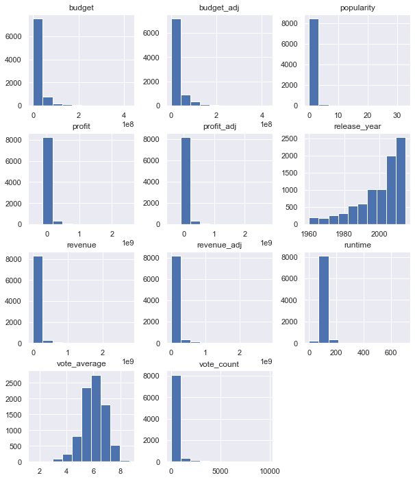

```python
df.hist(figsize=(10,12));
```

> - By looking at histograms quickly, we can see that more movies are release almost every year since 1960s.

## Exploratory Data Analysis

### 1. What is the trend of number of movies released each year?

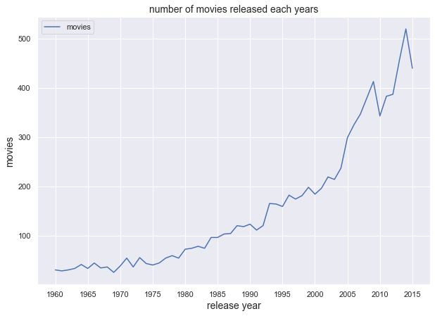

```python
df_movies = df.groupby(['release_year']).agg(movies=('original_title', 'count'))

df_movies.head(60).plot(xticks = np.arange(1960,2016,5),figsize=(10,7))

#setup the title of the figure
plt.title("number of movies released each years",fontsize = 14)

#setup the x-label and y-label of the plot.
plt.xlabel('release year',fontsize = 14)
plt.ylabel('movies',fontsize = 14)
```

### 2. Is that certain casts and director work together to make profitable movies?

```python
#Create a dataset for movies made $100M or more profit

df_profited = df[df['profit_adj'] >= 100000000]

#Create a subset of above dataset to limit that to recent years
df_recent_years = df_profited[df_profited['release_year'] >= 2009]
```

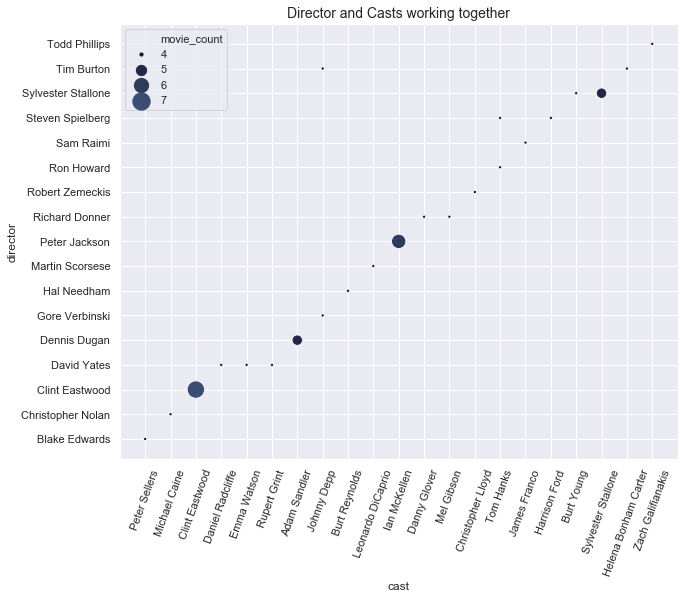

```python
#Split cast

df_cast = df_profited.assign(cast = df_profited['cast'].str.split('|')).explode('cast')

#Split director

df_cast_dir = df_cast.assign(director = df_cast['director'].str.split('|')).explode('director')

df_cast_dir['cast_director'] = df_cast_dir['director'] + ";" + df_cast_dir['cast']

df_merge = df_cast_dir.groupby('cast_director').agg(movie_count=('original_title', 'count'),cast=('cast','first'),director=('director','first'))

df_merge = df_merge[df_merge.movie_count > 3]
df_merge.drop(df_merge.index)
df_merge.sort_values(['movie_count'], ascending = False).head(20)

n = df_merge['movie_count'] * 0.02

cmap = sns.cubehelix_palette(dark=.3, light=.1,rot=-.2, as_cmap=True)

sns.scatterplot(x="cast", y="director",
                     hue="movie_count", size="movie_count",
                     palette=cmap, sizes=(10, 300),
                     data=df_merge)
plt.xticks(rotation=70)
plt.title('Director and Casts working together', fontsize = 14)

plt.show()
```

> - Some director also perform as cast for profitable movies. Ex. Clint Eastwood.
> - There is surely a relationship between director and cast performing multiple times together to make a profitable movies.
> - David Yates, Steven Spilberg, Sylvester Stallone and Tim Burton like to work with same casts repeatedly.

### 3. What are the most profitable, highest revenue and highest budget movies?

#### 3a. Most Profitable Movies

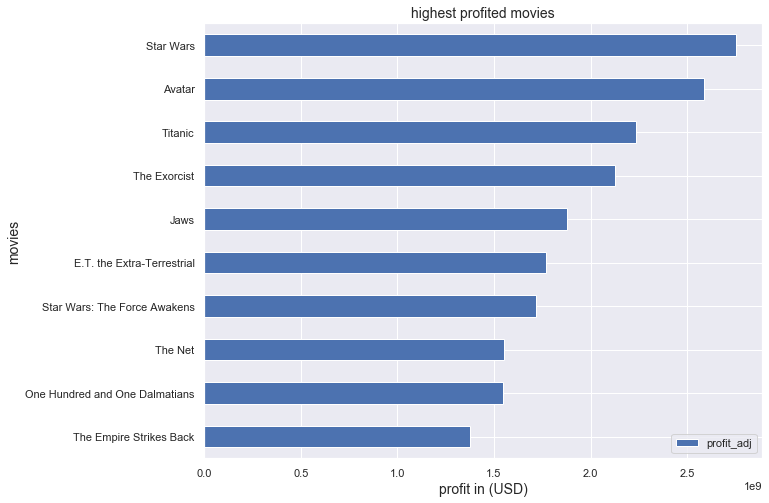

```python
#create new dataset for movie profit calculation

df_movie_profit = pd.melt(df, id_vars = ['original_title'], value_vars = ['profit_adj'], value_name = 'profit_adj')

df_movie_profit.sort_values(['profit_adj'], ascending = False).head(10).plot(kind = 'barh', x = 'original_title');
plt.gca().invert_yaxis()
# Graph features
plt.xlabel('profit in (USD)', fontsize = 14)
plt.ylabel('movies', fontsize = 14)
plt.title('highest profited movies', fontsize = 14)
```

#### 3b. High Revenue Movies

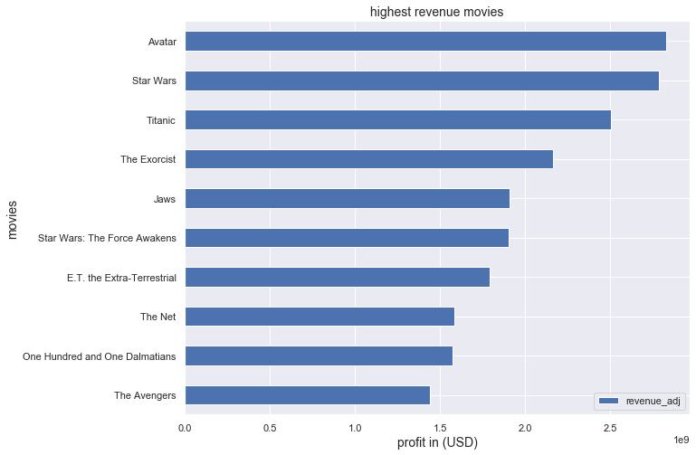

```python
#create new dataset for movie revenue calculation
df_movie_revenue = pd.melt(df, id_vars = ['original_title'], value_vars = ['revenue_adj'], value_name = 'revenue_adj')

df_movie_revenue.sort_values(['revenue_adj'], ascending = False).head(10).plot(kind = 'barh', x = 'original_title');

plt.gca().invert_yaxis()
# Graph features
plt.xlabel('profit in (USD)', fontsize = 14)
plt.ylabel('movies', fontsize = 14)
plt.title('highest revenue movies', fontsize = 14)
```

#### 3c. High Budget Movies

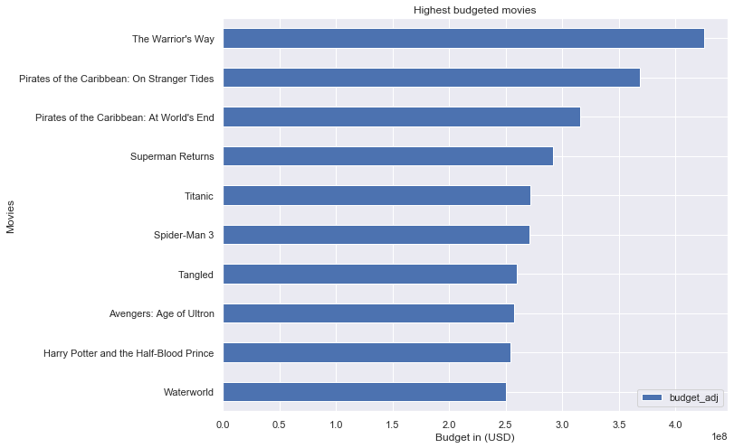

```python
#create new dataset for movie budget calculation
df_movie_budget = pd.melt(df, id_vars = ['original_title'], value_vars = ['budget_adj'], value_name = 'budget_adj')

df_movie_budget.sort_values(['budget_adj'], ascending = False).head(10).plot(kind = 'barh', x = 'original_title');

plt.gca().invert_yaxis()
plt.title("Highest budgeted movies")
plt.ylabel("Movies")
plt.xlabel("Budget in (USD)")
```

> - The most profitable movie is **Star wars** followed by **Avatar** and **Titanic**. Those movies also generated highest revenue.
> - However, only **Titanic** is listed as one the top highest budget movies.
> - **The Warrier's Way** is highest budgeted movie and that did not come up as a profitable movie.

### 4. What is the highest revenue movie in each of recent years?

[figure not shown]

```python
df_max_rev = df_recent_years.groupby(['release_year']).agg(revenue_max=('revenue_adj', max),movie=('original_title', 'first'),year=('release_year',min))

high_revenue = df_max_rev['revenue_max'].to_numpy()
movies = df_max_rev['movie'].to_numpy()
year = df_max_rev['year'].to_numpy()

g = sns.barplot(data=df_max_rev,x = movies, y = high_revenue, color = "b");
plt.xticks(rotation=70)
plt.tight_layout()
i = 0

for p in g.patches:
        x = p.get_x() + 0.2
        y = p.get_y() + p.get_height()
        g.annotate(year[i], (x, y))
        i +=1

# Graph features
plt.xlabel('movies release year', fontsize = 14)
plt.ylabel('revenue', fontsize = 14)
plt.title('most profitable movies per year', fontsize = 14)
```

> - **Avatar** has scored the highest revenue in recent years.

### 5. What is the corelation between budget, revenue and profit in recent years?

[figure not shown]

```python
df_invest = pd.DataFrame(df_recent_years,columns=['profit_adj','revenue_adj','budget_adj'])

cor = df_invest.corr()

x_axis_labels = ['profit','revenue','budget'] # labels for x-axis
y_axis_labels = ['budget','revenue','profit'] # labels for y-axis
sns.heatmap(cor, annot=True,xticklabels=x_axis_labels, yticklabels=y_axis_labels)
plt.show()
```

> - There is some corelation between budget Adjusted, Revenue Adjusted and Profit Adjusted. If budget is higher, there are higher chances of earning higher revenue. For most of the higher revenue movies, there is corelation of having good proift as well.

### 6. Which Genres are more profitable in recent years?

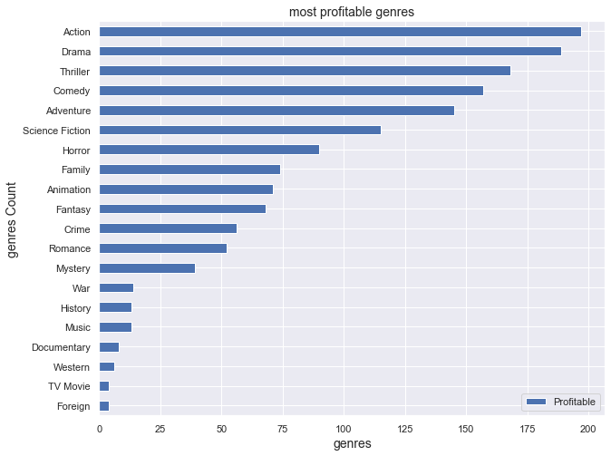

```python
#Split Genres
df_genres = df_recent_years.assign(genres = df_recent_years['genres'].str.split('|')).explode('genres')

#Create a temporary dataset to plot
df_g = df_genres.groupby(['genres'])['release_year'].count().to_frame(name = 'Profitable')

df_g.sort_values(['Profitable'], ascending = False).head(20).plot(kind = 'barh')
plt.gca().invert_yaxis()
# Graph features
plt.xlabel('genres', fontsize = 14)
plt.ylabel('genres Count', fontsize = 14)
plt.title('most profitable genres', fontsize = 14)
```

> - The most profitable genres are **Action, Drama, Thriller** and **Comedy** in recent years.